# RV Case Assessment

Tejas Padmanabhan

2024-10-11

Download all of the libraries

Download the excel file

```r
Bankrate <- read_xlsx("Bankrate.xlsx")
```

Question 1: Explain the variable relationships in terms of loan approval

```r
#Original model
Bankratemodel <- glm(Approved ~ Loan_Amount + FICO_score + Monthly_Gross_Income + Monthly_Housing_Payment, data = Bankrate, family = binomial)
BIC(Bankratemodel)
```

```
## [1] 59960.15
```

```r
#Association between Loan Amount and FICO Score
Bankratemodel1 <- glm(Approved ~ Loan_Amount + FICO_score + Monthly_Gross_Income + Monthly_Housing_Payment + Loan_Amount:FICO_score, data = Bankrate, family = binomial)
BIC(Bankratemodel1)
```

```
## [1] 59969.22
```

```r
#Association between Monthly Housing Payment and FICO Score
Bankratemodel2 <- glm(Approved ~ Loan_Amount + FICO_score + Monthly_Gross_Income + Monthly_Housing_Payment + Monthly_Housing_Payment:FICO_score, data = Bankrate, family = binomial)
BIC(Bankratemodel2)
```

```
## [1] 59935.83
```

```r
#Association between Loan Amount and Monthly Gross Income
Bankratemodel3 <- glm(Approved ~ Loan_Amount + FICO_score + Monthly_Gross_Income + Monthly_Housing_Payment + Monthly_Gross_Income:Loan_Amount, data = Bankrate, family = binomial)
BIC(Bankratemodel3)
```

```
## [1] 59938.44
```

```r
#Association between Monthly Gross Income and FICO Score
Bankratemodel4 <- glm(Approved ~ Loan_Amount + FICO_score + Monthly_Gross_Income + Monthly_Housing_Payment + Monthly_Gross_Income:FICO_score, data = Bankrate, family = binomial)
BIC(Bankratemodel4)
```

```
## [1] 59956.04
```

```r
#Association between Loan Amount and Monthly Housing Payment
Bankratemodel5 <- glm(Approved ~ Loan_Amount + FICO_score + Monthly_Gross_Income + Monthly_Housing_Payment + Monthly_Housing_Payment:Loan_Amount, data = Bankrate, family = binomial)
BIC(Bankratemodel5)
```

```
## [1] 59969.26
```

In order to determine what variables have the most impact on loan approval, I ran multiple GLM’s to see if different models had an effect on approval. I used BIC as a tool to determine this. And from my findings, I determined relationships between Loan Amount, Monthly Gross Income, FICO Score, and Monthly Housing Payment.

```r
#New Transformation
Bankrate$Loan_Income <- Bankrate$Loan_Amount / Bankrate$Monthly_Gross_Income
Bankratemodel6 <- glm(Approved ~ Loan_Amount + FICO_score + Loan_Income + Monthly_Housing_Payment,
                        data = Bankrate, family = binomial)
BIC(Bankratemodel6)
```

```
## [1] 59886.74
```

I also created a transformation by making a Loan Amount to Income ratio to make a more simpler and efficient model

```r
Bankrate$Housing_Cat <- cut_interval(Bankrate$Monthly_Housing_Payment, n = 3)
```

This function was created to create groups for monthly housing payments

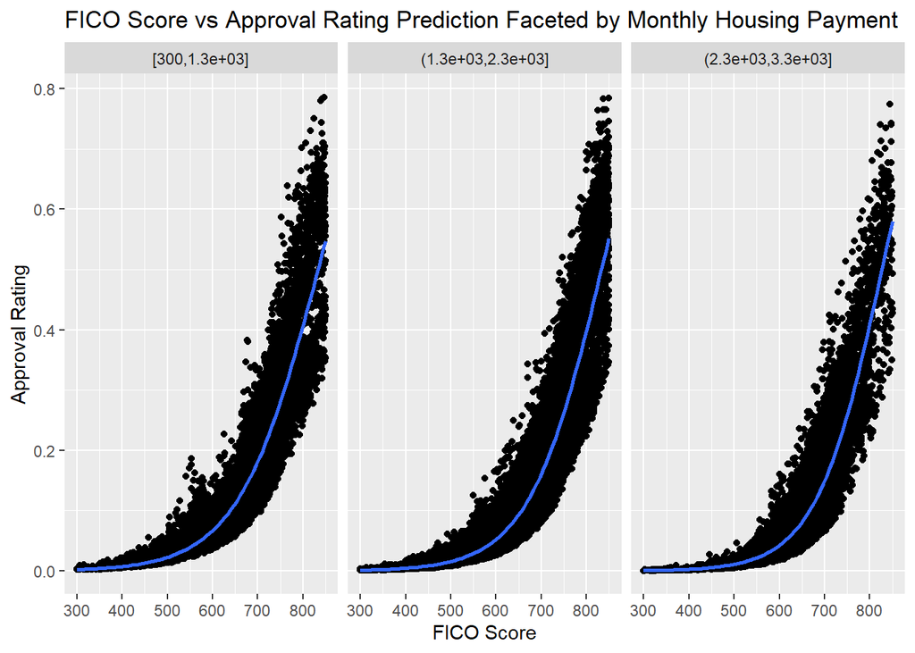

```r
#Association between Monthly Housing Payment and FICO Score
Bankratemodel1.pred <- predict(Bankratemodel2, newdata = Bankrate, type = "response")
Bankrate <- data.frame(Bankrate, pred1 = Bankratemodel1.pred)
ggplot(Bankrate, aes(x = FICO_score , y = pred1)) +
  geom_point() +
  geom_smooth(method = "glm", method.args = list(family = "binomial"), se = FALSE) +
  facet_wrap(~Bankrate$Housing_Cat) +
  labs(title = "FICO Score vs Approval Rating Prediction Faceted by Monthly Housing Payment",
       x = "FICO Score",
       y = "Approval Rating")
```

```r
Bankrate$Loan_Amount_Cat <- cut_interval(Bankrate$Loan_Amount, n = 3)
```

This function was created to create groups for loan amounts

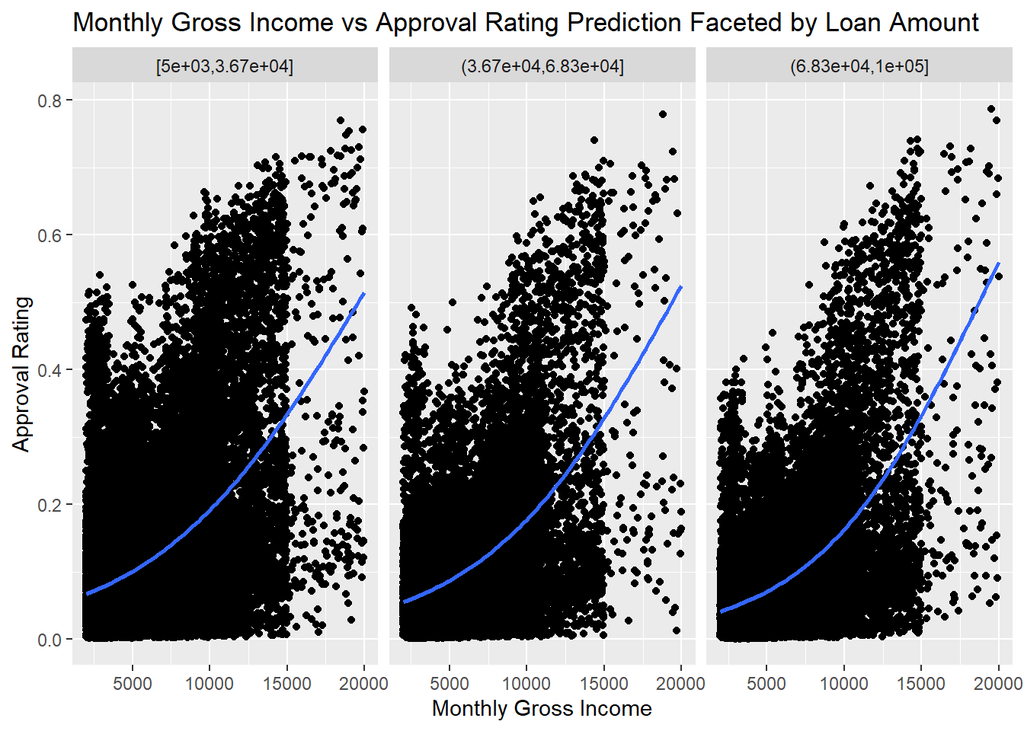

```r
#Association between Loan Amount and Monthly Gross Income
Bankratemodel2.pred <- predict(Bankratemodel3, newdata = Bankrate, type = "response")
Bankrate <- data.frame(Bankrate, pred2 = Bankratemodel2.pred)
ggplot(Bankrate, aes(x = Monthly_Gross_Income , y = pred2)) +
  geom_point() +
  geom_smooth(method = "glm", method.args = list(family = "binomial"), se = FALSE) +
  facet_wrap(~Bankrate$Loan_Amount_Cat) +
  labs(title = "Monthly Gross Income vs Approval Rating Prediction Faceted by Loan Amount",
       x = "Monthly Gross Income",
       y = "Approval Rating")
```

The clear takeaway from this model was that Regardless of the categories of Loan Amount, there remained a clear and consistent increase of of approval rating as monthly gross income also rose.

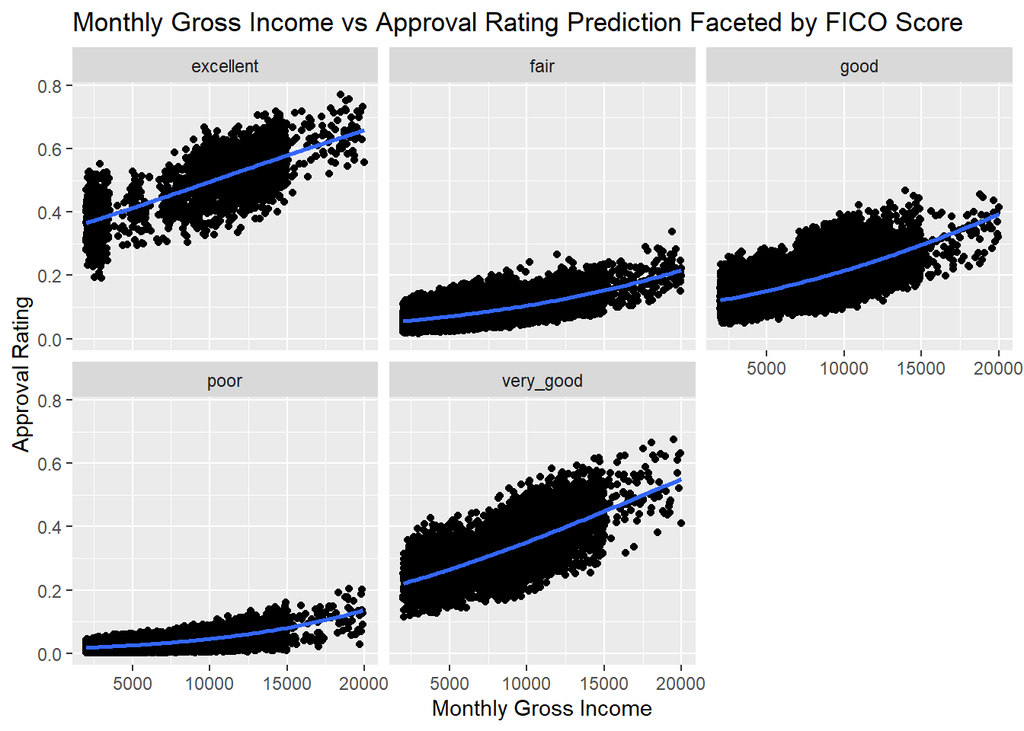

```r
#Association between Monthly Gross Income and FICO Score
Bankratemodel3.pred <- predict(Bankratemodel4, newdata = Bankrate, type = "response")
Bankrate <- data.frame(Bankrate, pred3 = Bankratemodel3.pred)
ggplot(Bankrate, aes(x = Monthly_Gross_Income , y = pred3)) +
  geom_point() +
  geom_smooth(method = "glm", method.args = list(family = "binomial"), se = FALSE) +
  facet_wrap(~Bankrate$Fico_Score_group) +
   labs(title = "Monthly Gross Income vs Approval Rating Prediction Faceted by FICO Score",
       x = "Monthly Gross Income",
       y = "Approval Rating")
```

As we can see from this model, There is an increase in approval rating regardless of FICO score as Income goes up. However, it is clear that the better the FICO score, the better the approval for a loan.

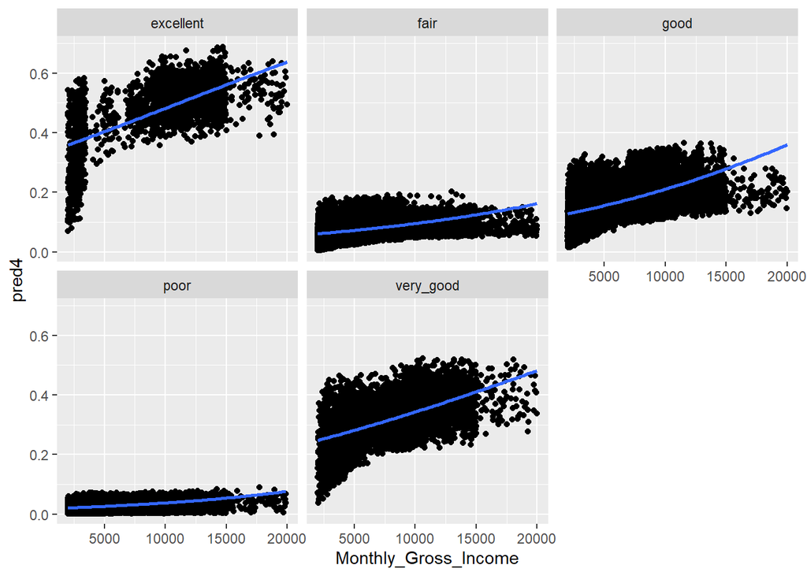

```r
#Transformation Model
#Association between Monthly Gross Income and FICO Score
Bankratemodel4.pred <- predict(Bankratemodel6, newdata = Bankrate, type = "response")
Bankrate <- data.frame(Bankrate, pred4 = Bankratemodel4.pred)
ggplot(Bankrate, aes(x = Monthly_Gross_Income , y = pred4)) +
  geom_point() +
  geom_smooth(method = "glm", method.args = list(family = "binomial"), se = FALSE) +
  facet_wrap(~Bankrate$Fico_Score_group)
```

In this model, I created a transformation to simplify the model and there is a clear difference from the last model in terms of slope of increase in approval rating as Income rises. The poor category is a clear sign that this model is more efficient as it does not have as high of a slope. The slope unlike the previous model as FICO Score group goes up increases which is what I initially thought I was going to see from this data.

Question 2: Learning about Lenders Approval Rates

```r
approval_rates <- Bankrate %>%
  group_by(Lender) %>%
  summarise(approval_rate = mean(Approved, na.rm = TRUE))

print(approval_rates)
```

```
## # A tibble: 3 × 2
##   Lender approval_rate
##   <chr>          <dbl>
## 1 A             0.110
## 2 B             0.0713
## 3 C             0.171
```

I simply took the raw approval score here for each lender

```r
fico_approval_rates <- Bankrate %>%
  group_by(Lender, Fico_Score_group) %>%
  summarise(approval_rate = mean(Approved, na.rm = TRUE))
print(fico_approval_rates)
```

```
## # A tibble: 15 × 3
## # Groups:   Lender [3]
##    Lender Fico_Score_group approval_rate
##    <chr>  <chr>                    <dbl>
##  1 A      excellent               0.444
##  2 A      fair                    0.0657
##  3 A      good                    0.180
##  4 A      poor                    0.0263
##  5 A      very_good               0.358
##  6 B      excellent               0.433
##  7 B      fair                    0.0154
##  8 B      good                    0.136
##  9 B      poor                    0
## 10 B      very_good               0.298
## 11 C      excellent               0.546
## 12 C      fair                    0.130
## 13 C      good                    0.260
## 14 C      poor                    0.0755
## 15 C      very_good               0.492
```

Here I took the approval rating and grouped it by the FICO Score groups.

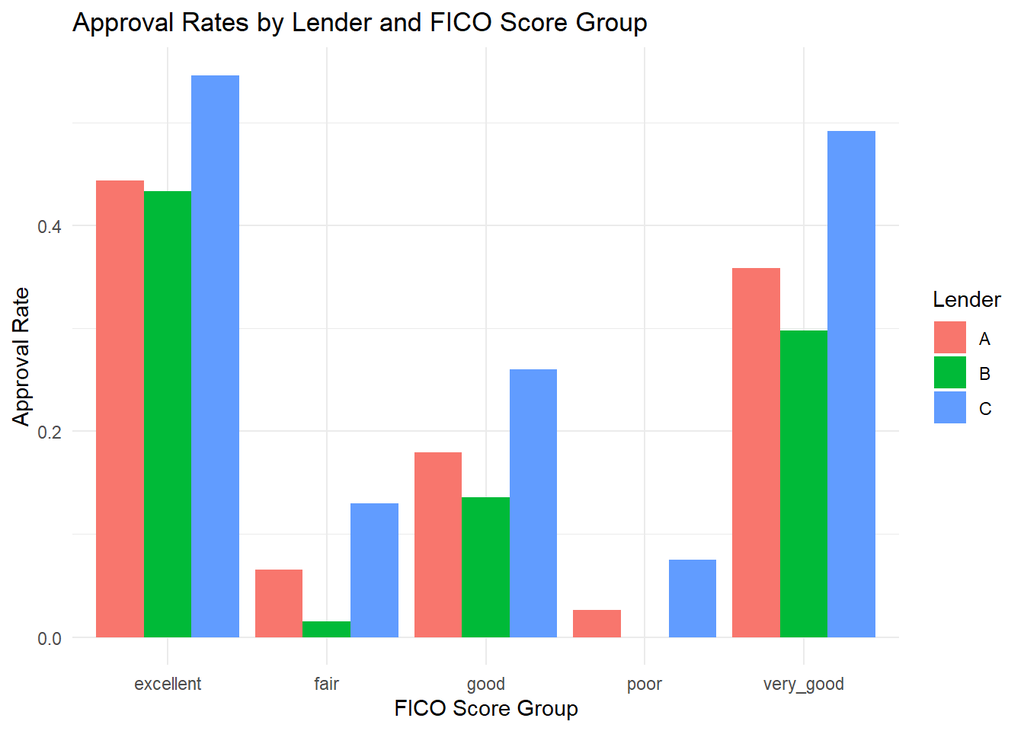

```r
ggplot(fico_approval_rates, aes(x = Fico_Score_group, y = approval_rate, fill = Lender)) +
  geom_bar(stat = "identity", position = "dodge") +
  labs(title = "Approval Rates by Lender and FICO Score Group",
       x = "FICO Score Group",
       y = "Approval Rate") +
  theme_minimal()
```

Here is a simple Bar chart describing the previous code. As we can see As the higher FICO Score the better approval rate. In terms of Lenders, It seems that for all of the FICO Scores, Lender C is the prominent lender in terms of approving loans. Lender B seems to be the pickiest of the lenders as in each FICO score category they approve the least amount of loans out of all the lenders.

```r
Bankrate$Gross_Income_Cat <- cut_interval(Bankrate$Monthly_Gross_Income, n = 5)

income_approval_rates <- Bankrate %>%
  group_by(Lender, Gross_Income_Cat) %>%
  summarise(approval_rate = mean(Approved, na.rm = TRUE))
```

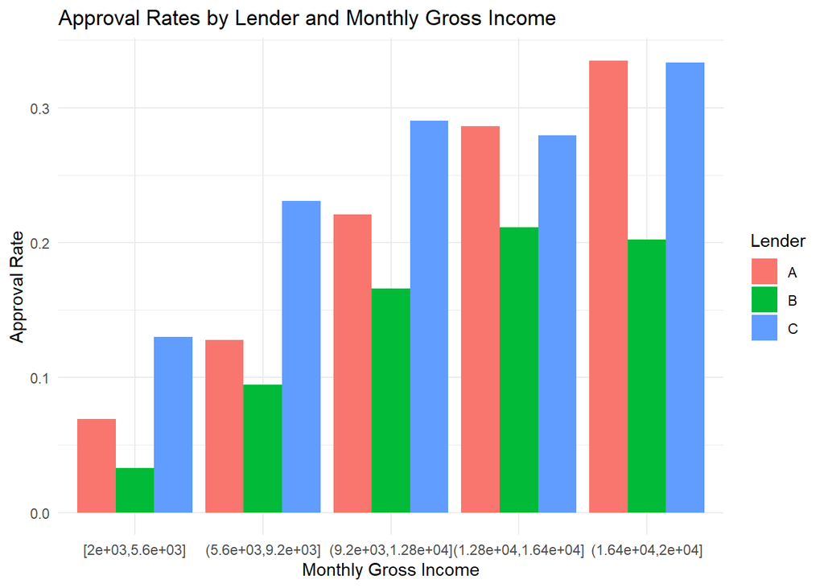

```r
ggplot(income_approval_rates, aes(x = Gross_Income_Cat, y = approval_rate, fill = Lender)) +
  geom_bar(stat = "identity", position = "dodge") +
  labs(title = "Approval Rates by Lender and Monthly Gross Income",
       x = "Monthly Gross Income",
       y = "Approval Rate") +
  theme_minimal()
```

From this simple bar chart, as Income rises, lenders seem to give out more approval for loans. Lender C seems to be the most lenient of the lenders as even when income is low, they have the highest approval rating out of all the lenders.

```r
reason_approval_rates <- Bankrate %>%
  group_by(Lender, Reason) %>%
  summarise(approval_rate = mean(Approved, na.rm = TRUE))
```

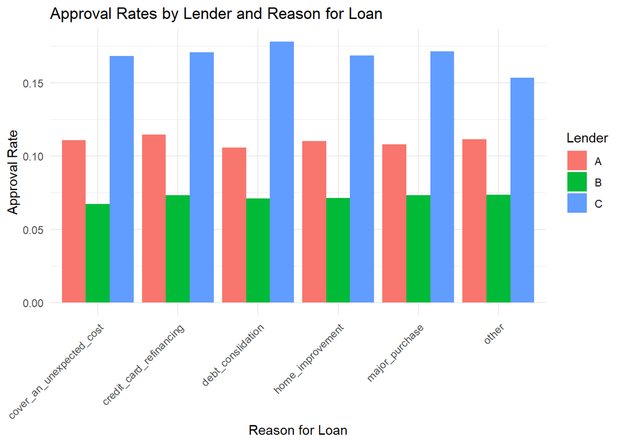

```r
ggplot(reason_approval_rates, aes(x = Reason, y = approval_rate, fill = Lender)) +
  geom_bar(stat = "identity", position = "dodge") +
  labs(title = "Approval Rates by Lender and Reason for Loan",
       x = "Reason for Loan",
       y = "Approval Rate") +
  theme_minimal() +
  theme(axis.text.x = element_text(angle = 45, hjust = 1))
```

With this bar chart, even across different reasons we see that Lender C gives out the most approval for loans and Lender B is the pickiest.

Question 3 3. Evaluate which customers we should match to each lender to maximize Revenue Per Application

```r
Bankrate <- Bankrate %>%
  mutate(Monthly_Income_Group = cut(Monthly_Gross_Income,
                                    breaks = c(-Inf, 5000, 10000, 15000, Inf),
                                    labels = c("Low", "Medium", "High", "Very High")))
```

My first move for this question was to create categories for Gross Income to make it simpler for me to find approval ratings.

```r
options(tibble.print_max = Inf, tibble.print_min = Inf)
approval_rates_by_group <- Bankrate %>%
  group_by(Fico_Score_group, Monthly_Income_Group, Lender) %>%
  summarise(
    approved_count = sum(Approved, na.rm = TRUE),
    total_count_per_lender = n(),
    approval_rate = approved_count / total_count_per_lender
  ) %>%
  ungroup()
```

```
## You can override using the `.groups` argument.
```

```r
bounty_lookup <- data.frame(
  Lender = c("A", "B", "C"),
  Bounty = c(250, 350, 150)
)

approval_rates_by_group <- approval_rates_by_group %>%
  left_join(bounty_lookup, by = "Lender") %>%
  mutate(score = approval_rate * Bounty)

optimal_lender_by_group <- approval_rates_by_group %>%
  group_by(Fico_Score_group, Monthly_Income_Group) %>%
  filter(score == max(score)) %>%  # Select lender with max score
  summarise(
    optimal_lender = first(Lender),       # Optimal lender with max score
    optimal_approval_rate = first(approval_rate),
    optimal_bounty = first(Bounty)
  ) %>%
  ungroup()
total_count_by_group <- Bankrate %>%
  group_by(Fico_Score_group, Monthly_Income_Group) %>%
  summarise(total_count = n()) %>%
  ungroup()
optimal_lender_by_group <- optimal_lender_by_group %>%
  left_join(total_count_by_group, by = c("Fico_Score_group", "Monthly_Income_Group")) %>%
  mutate(new_revenue = optimal_approval_rate * optimal_bounty * total_count)

current_revenue_by_group <- approval_rates_by_group %>%
  mutate(expected_revenue = approval_rate * Bounty * total_count_per_lender) %>%
  group_by(Fico_Score_group, Monthly_Income_Group) %>%
  summarise(current_revenue = sum(expected_revenue)) %>%
  ungroup()
incremental_revenue <- optimal_lender_by_group %>%
  left_join(current_revenue_by_group, by = c("Fico_Score_group", "Monthly_Income_Group")) %>%
  mutate(incremental_revenue = new_revenue - current_revenue)

datatable(incremental_revenue, options = list(pageLength = 100, autoWidth = TRUE))
```

|  | Fico_Score_group | Monthly_Income_Group | optimal_lender | optimal_approval_rate | optimal_bounty | total_count | new_revenue | current_revenue | incremental_revenue |
| --- | --- | --- | --- | --- | --- | --- | --- | --- | --- |
| 1 | excellent | Low | A | 0.4396887159533074 | 250 | 532 | 58478.59922178988 | 48700 | 9778.599221789882 |
| 2 | excellent | Medium | B | 0.4527027027027027 | 350 | 475 | 75261.82432432432 | 54500 | 20761.82432432432 |
| 3 | excellent | High | B | 0.4954682779456193 | 350 | 1093 | 189541.3897280967 | 143950 | 45591.38972809666 |
| 4 | excellent | Very High | B | 0.5 | 350 | 88 | 15400 | 10550 | 4850 |
| 5 | fair | Low | C | 0.09250065325320093 | 150 | 16528 | 229327.6195453358 | 174950 | 54377.61954533576 |
| 6 | fair | Medium | C | 0.1765785609397944 | 150 | 17500 | 463518.7224669604 | 289950 | 173568.7224669604 |
| 7 | fair | High | C | 0.15625 | 150 | 2295 | 53789.0625 | 42650 | 11139.0625 |
| 8 | fair | Very High | C | 0.4347826086956522 | 150 | 152 | 9913.04347826087 | 3750 | 6163.04347826087 |
| 9 | good | Low | C | 0.2160148975791434 | 150 | 9600 | 311061.4525139664 | 297700 | 13361.45251396642 |
| 10 | good | Medium | B | 0.1579929988331389 | 350 | 15501 | 857167.31621937 | 735600 | 121567.31621937 |

[output cut: 10 more lines]

In this process, I first calculated the approval rates for each lender (A, B, C) by grouping customers based on their FICO score and income levels. I then multiplied the approval rates by the bounty to find the best combination of approval rate and payment for each lender. Next, I identified the optimal lender for each FICO score and income group by selecting the lender with the highest score. After that, I calculated the total revenue we would earn if all customers in each group were sent to the optimal lender. I also calculated the current revenue based on how customers are currently assigned to lenders. Finally, I compared the two to calculate the potential extra revenue (incremental revenue) we could earn by switching to the optimal lender for each customer group. This approach helps determine the best way to assign customers to maximize revenue.